# latex

### Resulting text

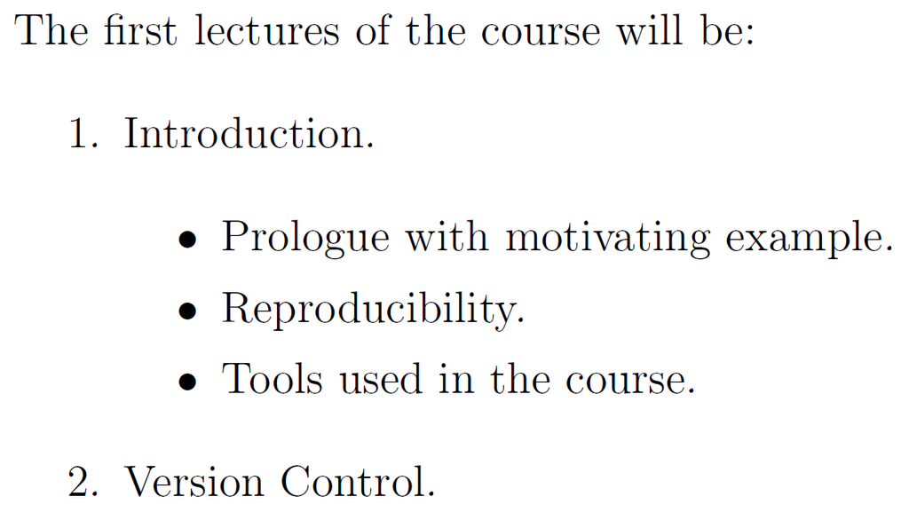

Course outline

## Math environments

- Math has special environment delimiters
  - `\( ... \)` for inline math
  - `\[ ... \]` for single-line math
- Subscripts via underscores, superscripts via circumflex in math environments …
  - Strange errors in usual text – use `\_` and `\^`
  - “Escape characters”
- Curly braces delimit groups (e.g. what goes in a subscript or denominator)
- Greek letters via commands in math mode: `\alpha`, `\Delta`

## Source code for math examples

```latex
Two important measures for individuals' risk aversion
are based on the curvature of a utility function
\( u (x) \) over a monetary quantity \( x \).

These are absolute risk aversion:
\[
    r_A (x) = -\frac{u^{''} (x)}{u^{'} (x)}
\]
and relative risk aversion:
\[
    r_R (x) = - x \cdot \frac{u^{''} (x)}{u^{'} (x)}
\]
```

## Resulting text

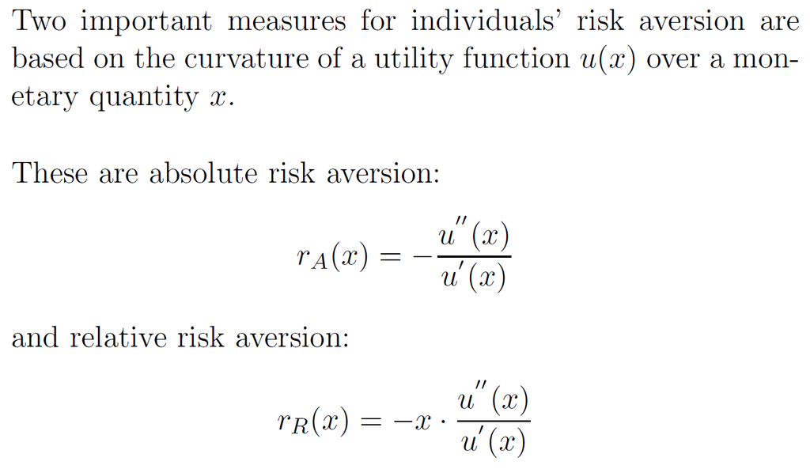

Math example

## The preamble

    vs.

    ```latex
    \usepackage[latin1]{inputenc}
    ```

  - Save file with appropriate encoding (prefer UTF-8!)
- No reason to worry much, use templates and don’t start from scratch!

## Compiling documents to pdf’s

- Use pdflatex
  - Forget about old documentation floating around (dvi’s)
  - Specialised editors have extensions or built-in interfaces
- Might need several runs, other programs to run in between
  - Not yet
  - Use automated tools later
- Error messages not too helpful
  - Focus on line numbers
  - General feature of LaTeX compilation tools

## Tables

- **Always** use the [booktabs](https://ctan.org/pkg/booktabs?lang=en) package
- Read [Fear (2005)](https://ctan.space-pro.be/tex-archive/macros/latex/contrib/booktabs/booktabs.pdf) for usage
- Read [Fear (2005)](https://ctan.space-pro.be/tex-archive/macros/latex/contrib/booktabs/booktabs.pdf) for style rules

## Bibliographies

- Bibliographies one of the big strengths of LaTeX
- Pull everything out of centralised file (database)
  - Has a peculiar format
  - Use manager, e.g. Jabref on all platforms, BibDesk on Mac
- Historically: [bibtex](http://www.bibtex.org/)
- Modern: [biblatex & biber](http://biblatex-biber.sourceforge.net/)